# Tarea 5

# Tarea 5.

# Metodos supervisados

Librerias

```r
library('GGally')
```

```r
library('ggplot2')
library('caTools')
library('rpart')
library('randomForest')
library('rpart.plot')
library('ROCR')
library('dplyr')
library('visdat')
library('cba')
library('caret')
library('pROC')
library('GoodmanKruskal')
```

## 1. Desarolle el Análisis del Problema

Este conjunto de datos incluye descripciones de muestras hipotéticas correspondientes a 23 especies de hongos branquiales en el hongo de la familia Agaricus y Lepiota extraídas de la Guía de campo de la Sociedad Audubon de hongos de América del Norte (1981). Cada especie se identifica como definitivamente comestible, definitivamente venenosa o de comestibilidad desconocida y no se recomienda. Esta última clase se combinó con la venenosa. La Guía establece claramente que no existe una regla simple para determinar la comestibilidad de un hongo; ninguna regla como “folletos tres, que así sea” para el roble venenoso y la hiedra.

Las reglas lógicas dadas a continuación parecen ser las más simples posibles para el conjunto de datos de hongos, por lo tanto, deben tratarse como resultados de referencia.

Reglas disyuntivas para hongos venenosos, de la mayoría en general a lo más específico:

- P1) odor=NOT(almond.OR.anise.OR.none) 120 casos venenosos perdidos, 98.52% de precisión
- P2) spore-print-color=green 48 casos perdidos, 99.41% de precisión
- P3) odor=none.AND.stalk-surface-below-ring=scaly.AND.(stalk-color-above-ring=NOT.brown) 8 casos perdidos, 99.90% de precisión
- P4) habitat=leaves.AND.cap-color=white 100% de precisión
- P4) population=clustered.AND.cap_color=white

Estas reglas involucran 6 atributos (de 22).

Reglas para comestibles: los hongos se obtienen como negación de las reglas dadas anteriormente.

- Información: (class: edible, poisonous)
  1. *cap-shape:* bell=b,conical=c,convex=x,flat=f, knobbed=k,sunken=s
  2. *cap-surface:* fibrous=f,grooves=g,scaly=y,smooth=s
  3. *cap-color:* brown=n,buff=b,cinnamon=c,gray=g,green=r,pink=p,purple=u,red=e,white=w,yellow=y
  4. *bruises?:* bruises=t,no=f
  5. *odor:* almond=a,anise=l,creosote=c,fishy=y,foul=f,musty=m,none=n,pungent=p,spicy=s
  6. *gill-attachment:* attached=a,descending=d,free=f,notched=n
  7. *gill-spacing:* close=c,crowded=w,distant=d
  8. *gill-size:* broad=b,narrow=n
  9. *gill-color:* black=k,brown=n,buff=b,chocolate=h,gray=g,green=r,orange=o,pink=p,purple=u,red=e,white=w,yellow=y
  10. *stalk-shape:* enlarging=e,tapering=t
  11. *stalk-root:* bulbous=b,club=c,cup=u,equal=e,rhizomorphs=z,rooted=r,missing=?
  12. *stalk-surface-above-ring:* fibrous=f,scaly=y,silky=k,smooth=s
  13. *stalk-surface-below-ring:* fibrous=f,scaly=y,silky=k,smooth=s
  14. *stalk-color-above-ring:* brown=n,buff=b,cinnamon=c,gray=g,orange=o,pink=p,red=e,white=w,yellow=y
  15. *stalk-color-below-ring:* brown=n,buff=b,cinnamon=c,gray=g,orange=o,pink=p,red=e,white=w,yellow=y
  16. *veil-type:* partial=p,universal=u
  17. *veil-color:* brown=n,orange=o,white=w,yellow=y
  18. *ring-number:* none=n,one=o,two=t
  19. *ring-type:* cobwebby=c,evanescent=e,flaring=f,large=l,none=n,pendant=p,sheathing=s,zone=z
  20. *spore-print-color:* black=k,brown=n,buff=b,chocolate=h,green=r,orange=o,purple=u,white=w,yellow=y
  21. *population:* abundant=a,clustered=c,numerous=n,scattered=s,several=v,solitary=y
  22. *habitat:* grasses=g,leaves=l,meadows=m,paths=p,urban=u,waste=w,woods=d

Fuente del dataset: https://archive.ics.uci.edu/ml/machine-learning-databases/mushroom/agaricus-lepiota.data

Requerimiento: Clasificar los hongos en dos tipos **edible** y **poisonous** utilizando 3 tipos de modelos de aprendizaje supervisado

## 1. Cargue el archivo agaricus_lepiota.data.csv en una variable

```r
# # Carga de datos
# agaricus_col_names <-
#     c(
#         "class",
#         "cap.shape",
#         "cap.surface",
#         "cap.color",
#         "bruises",
#         "odor",
#         "gill.attachment",
#         "gill.spacing",
#         "gill.size",
#         "gill.color",
#         "stalk.shape",
#         "stalk.root",
#         "stalk.surface.above.ring",
#         "stalk.surface.below.ring",
#         "stalk.color.above.ring",
#         "stalk.color.below.ring",
#         "veil.type",
#         "veil.color",
#         "ring.number",
#         "ring.type",
#         "spore.print.color",
#         "population",
#         "habitat"
#     )

# Parámetro na.strings = '?' para que interprete los signos de pregunta como valores faltantes
# agaricus_data <- read.csv(
#     'agaricus-lepiota.data.csv',
#     header = F,
#     col.names = agaricus_col_names,
#     na.strings = '?'
# )

# Se agrega el paquete Mushroom de la librería cba para incorporar el dataset, de igual forma
# con el código comentado anteriormente podemos cargar el dataset desde nuestro archivo csv
data("Mushroom")

# Formatea los names de las variables
names(Mushroom) <- make.names(names(Mushroom))
```

## 2. Desarolle el Entendimiento de los Datos

```r
# Resultado de los datos

# Valores mínimos, máximos, mediana y media de cada columna
summary(Mushroom)
```

```
##        class        cap.shape     cap.surface     cap.color
##  edible   :4208   bell   : 452   fibrous:2320   brown  :2284
##  poisonous:3916   conical:   4   grooves:   4   gray   :1840
##                   convex :3656   scaly  :3244   red    :1500
##                   flat   :3152   smooth :2556   yellow :1072
##                   knobbed: 828                  white  :1040
##                   sunken :  32                  buff   : 168
##                                                 (Other): 220
##     bruises.         odor      gill.attachment  gill.spacing
##  bruises:3376   none   :3528   attached: 210   close  :6812
##  no     :4748   foul   :2160   free    :7914   crowded:1312
##                 fishy  : 576
##                 spicy  : 576
##                 almond : 400
##                 anise  : 400
##                 (Other): 484
##   gill.size        gill.color      stalk.shape     stalk.root
##  broad :5612   buff     :1728   enlarging:3516   bulbous:3776
##  narrow:2512   pink     :1492   tapering :4608   club   : 556
##                white    :1202                    equal  :1120
##                brown    :1048                    rooted : 192
##                gray     : 752                    NA's   :2480
##                chocolate: 732
##                (Other)  :1170
##  stalk.surface.above.ring stalk.surface.below.ring stalk.color.above.ring
##  ibrous: 552              ibrous: 600              white  :4464
##  scaly :  24              scaly : 284              pink   :1872
##  silky :2372              silky :2304              gray   : 576
##  smooth:5176              smooth:4936              brown  : 448
##                                                    buff   : 432
##                                                    orange : 192
##                                                    (Other): 140
##  stalk.color.below.ring   veil.type     veil.color   ring.number
##  white  :4384           partial:8124   brown :  96   none:  36
##  pink   :1872                          orange:  96   one :7488
##  gray   : 576                          white :7924   two : 600
##  brown  : 512                          yellow:   8
##  buff   : 432
##  orange : 192
##  (Other): 156
##       ring.type    spore.print.color     population      habitat
##  evanescent:2776   white    :2388    abundant : 384   grasses:2148
##  flaring   :  48   brown    :1968    clustered: 340   leaves : 832
##  large     :1296   black    :1872    numerous : 400   meadows: 292
##  none      :  36   chocolate:1632    scattered:1248   paths  :1144
##  pendant   :3968   green    :  72    several  :4040   urban  : 368
##                    buff     :  48    solitary :1712   waste  : 192
##                    (Other)  : 144                     woods  :3148
```

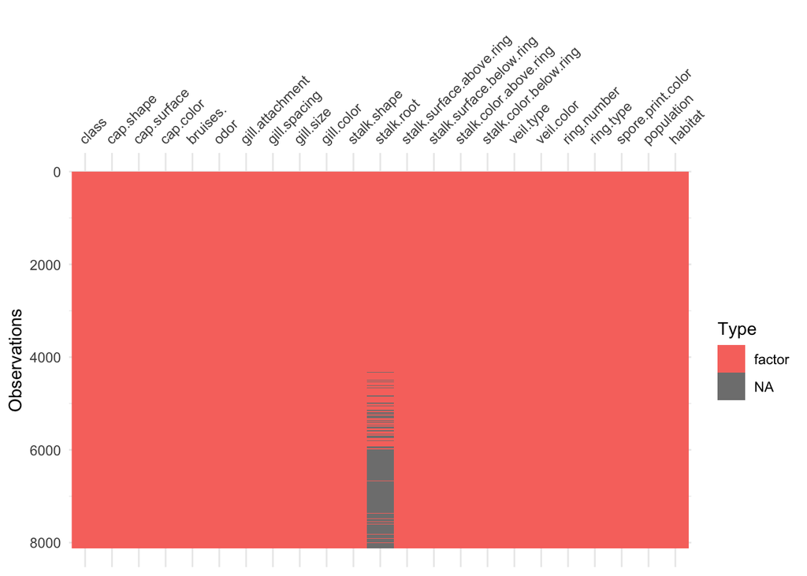

```r
# Visualización de tipos de datos
vis_dat(Mushroom)
```

```r
# Estructura del conjunto de datos
str(Mushroom)
```

```
## 'data.frame':    8124 obs. of  23 variables:
##  $ class                   : Factor w/ 2 levels "edible","poisonous": 2 1 1 2 1 1 1 1 2 1 ...
##  $ cap.shape               : Factor w/ 6 levels "bell","conical",..: 3 3 1 3 3 3 1 1 3 1 ...
##  $ cap.surface             : Factor w/ 4 levels "fibrous","grooves",..: 4 4 4 3 4 3 4 3 3 4 ...
##  $ cap.color               : Factor w/ 10 levels "brown","buff",..: 1 10 9 9 4 10 9 9 9 10 ...
##  $ bruises.                : Factor w/ 2 levels "bruises","no": 1 1 1 1 2 1 1 1 1 1 ...
##  $ odor                    : Factor w/ 9 levels "almond","anise",..: 8 1 2 8 7 1 1 2 8 1 ...
##  $ gill.attachment         : Factor w/ 2 levels "attached","free": 2 2 2 2 2 2 2 2 2 2 ...
##  $ gill.spacing            : Factor w/ 2 levels "close","crowded": 1 1 1 1 2 1 1 1 1 1 ...
##  $ gill.size               : Factor w/ 2 levels "broad","narrow": 2 1 1 2 1 1 1 1 2 1 ...
##  $ gill.color              : Factor w/ 12 levels "black","brown",..: 1 1 2 2 1 2 5 2 8 5 ...
##  $ stalk.shape             : Factor w/ 2 levels "enlarging","tapering": 1 1 1 1 2 1 1 1 1 1 ...
##  $ stalk.root              : Factor w/ 4 levels "bulbous","club",..: 3 2 2 3 3 2 2 2 3 2 ...
##  $ stalk.surface.above.ring: Factor w/ 4 levels "ibrous","scaly",..: 4 4 4 4 4 4 4 4 4 4 ...
##  $ stalk.surface.below.ring: Factor w/ 4 levels "ibrous","scaly",..: 4 4 4 4 4 4 4 4 4 4 ...
##  $ stalk.color.above.ring  : Factor w/ 9 levels "brown","buff",..: 8 8 8 8 8 8 8 8 8 8 ...
##  $ stalk.color.below.ring  : Factor w/ 9 levels "brown","buff",..: 8 8 8 8 8 8 8 8 8 8 ...
##  $ veil.type               : Factor w/ 1 level "partial": 1 1 1 1 1 1 1 1 1 1 ...
##  $ veil.color              : Factor w/ 4 levels "brown","orange",..: 3 3 3 3 3 3 3 3 3 3 ...
##  $ ring.number             : Factor w/ 3 levels "none","one","two": 2 2 2 2 2 2 2 2 2 2 ...
##  $ ring.type               : Factor w/ 5 levels "evanescent","flaring",..: 5 5 5 5 1 5 5 5 5 5 ...
##  $ spore.print.color       : Factor w/ 9 levels "black","brown",..: 1 2 2 1 2 1 1 2 1 1 ...
##  $ population              : Factor w/ 6 levels "abundant","clustered",..: 4 3 3 4 1 3 3 4 5 4 ...
##  $ habitat                 : Factor w/ 7 levels "grasses","leaves",..: 5 1 3 5 1 1 3 3 1 3 ...
```

```r
# Numero de fil as del dataset
nrow(Mushroom)
```

```
## [1] 8124
```

```r
# Revisar valores nulos del dataset
sum(is.na(Mushroom))
```

```
## [1] 2480
```

### Resultado breve de los datos

- Numero de registros: 8124
- Tipos de variables encontradas: 23 variables categóricas nominales
- Distribución de clases basado en el atributo **class**:

  edible: 4208 (51.8%) poisonous: 3916 (48.2%)
- El atributo **stalk.root** presenta 2480 valores nulos
- El atributo **veil.type** presenta unicamente el valor **partial**

## 3. Utilizando barplot cree un gráfico de los atributos del dataset, observe las correlaciones entre atributos

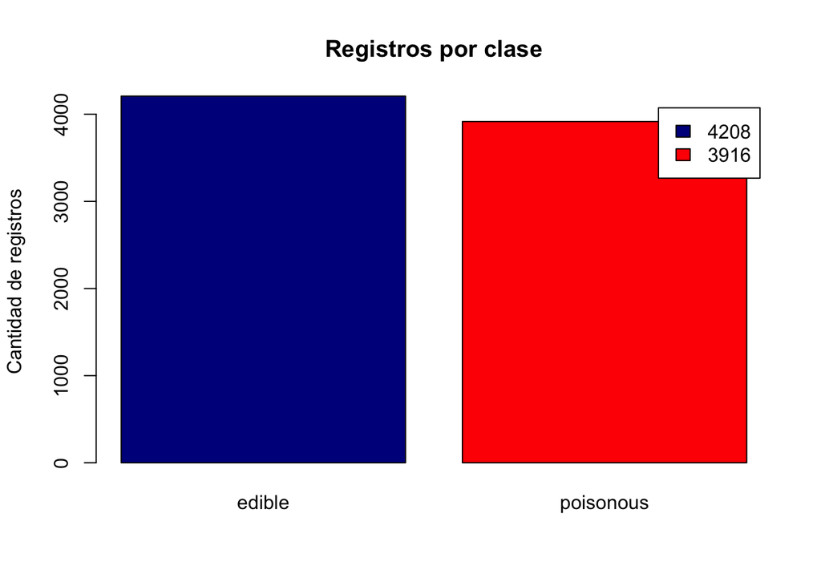

```r
# Cantidad de registros por región
class_count <- table(Mushroom$class)

# Registros por clase de hongo
barplot(
    table(Mushroom$class),
    main = "Registros por clase",
    ylab = "Cantidad de registros",
    col = c("darkblue", "red"),
    legend = class_count
)
```

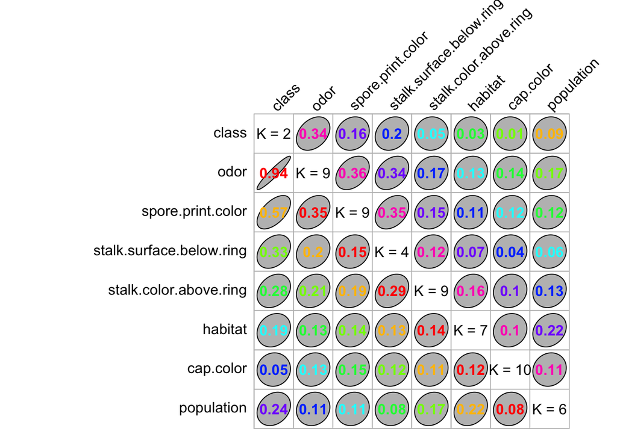

```r
# Gráfico de asociaciones entre variables categóricas
# Se utiliza Goodman and Kruskal’s tau para poder mediar la asociación entre variables
# Se utilizaron las variables recomendadas según el enunciado presentado anteriormente
mushroom_variable_names <-
    c(
        'class',
        'odor',
        'spore.print.color',
        'stalk.surface.below.ring',
        'stalk.color.above.ring',
        'habitat',
        'cap.color',
        'population'
    )

# Resultado de asociaciones entre variables, los valores más altos en relación con class son los valores que presentan
# mayor representación para determinar si es edible o poisonous
GKmatrix <- GKtauDataframe(subset(Mushroom, select = mushroom_variable_names))

plot(GKmatrix)
```

En el gráfico de arriba podemos observar la cantidad de registros por tipo de clase, donde 4208 pertenecen a **edible** y 3916 pertenecen a **poisonous**

En el gráfico de asociaciones podemos observar que las variables **odor** y **spore.print.color** son las que presentan mayor fuerza en relación a la clase, por lo que claramente representan puntos de partida para determinar si un hongo es de clase **edible** o **poisonous**

```r
# Cantidad de datos por nivel con la variable cap-shape
summary(Mushroom$cap.shape)
```

```
##    bell conical  convex    flat knobbed  sunken
##     452       4    3656    3152     828      32
```

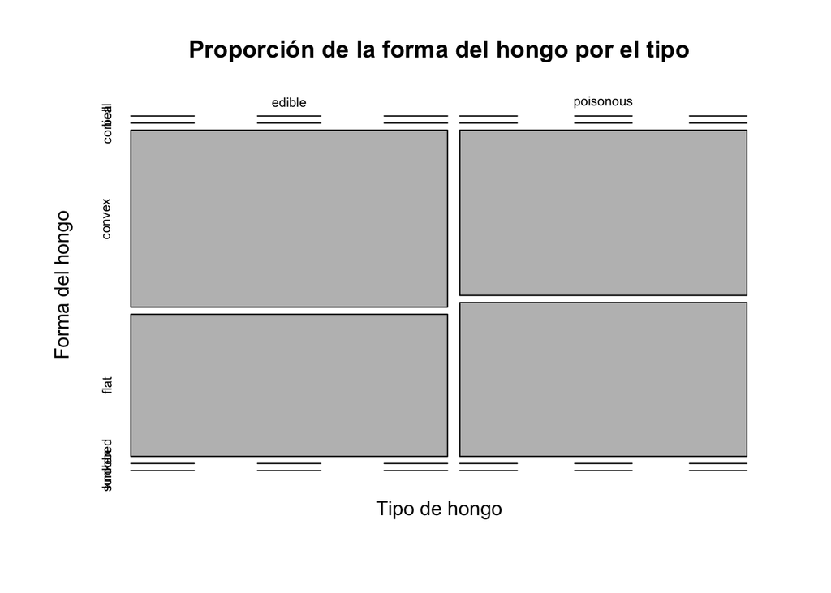

```r
# Evaluando convex & flat
mushroom_cap_shape_mosaic <- Mushroom %>% filter(cap.shape == c('convex','flat'))

mosaicplot(~mushroom_cap_shape_mosaic$class + mushroom_cap_shape_mosaic$cap.shape,
main = 'Proporción de la forma del hongo por el tipo',
ylab = 'Forma del hongo',
xlab = 'Tipo de hongo')
```

Del gráfico anterior, podemos concluir que la forma no es un factor radical para determinar si es venenoso o no, dado que para ambos cosas existen cantidades muy altas de la forma **convex** y **flat** por lo que es dificil determinar una forma muy acertada para disernir si es **edible** o **poisonous**

```r
# Cantidad de datos por nivel con la variable cap.shape
summary(Mushroom$habitat)
```

```
## grasses  leaves meadows   paths   urban   waste   woods
##    2148     832     292    1144     368     192    3148
```

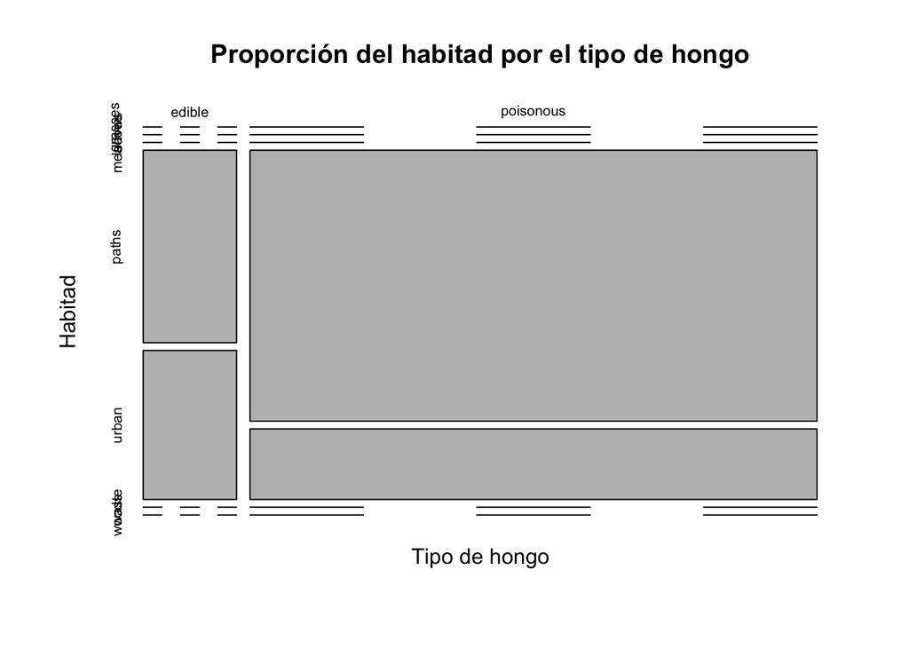

```r
# Evaluando urban & paths
mushroom_habitat_mosaic <- Mushroom %>% filter(habitat == c('urban','paths'))

mosaicplot(~mushroom_habitat_mosaic$class + mushroom_habitat_mosaic$habitat,
main = 'Proporción del habitad por el tipo de hongo',
ylab = 'Habitad',
xlab = 'Tipo de hongo')
```

```r
table(mushroom_habitat_mosaic$class,mushroom_habitat_mosaic$habitat)
```

```
##
##             grasses leaves meadows paths urban waste woods
##   edible          0      0       0    62    48     0     0
##   poisonous       0      0       0   530   138     0     0
```

Del gráfico anterior y tabla de resultados, notamos algo sumamente interesante con respecto a sus proporcionalidades, si notamos los valores como **urban** y **paths** podemos notar que estos valores tienen mayor proporcionalidad para **poisonous** esto puede deberse al hecho de que hay más posibilidades de que un hongo sea venenoso si proviene de lugares donde influyan directamente los humanos como lugares urbanos y caminos.

## 4. Realice al menos 3 modelos vistos en clase

### Preparación de los datos

```r
set.seed(123)

# Se transforma la variable class a factor
Mushroom$class <- factor(Mushroom$class)

# Datos de  entrenamiento 70% de las observaciones
# Datos de prueba con el restante 30% de las observaciones
mushroom_data_split <-
    sample.split(Mushroom$class, SplitRatio = 0.7)

# 70% de las observaciones
mushroom_data_training <- Mushroom[mushroom_data_split,]

# 30% de las observaciones
# Se omiten los valores que sean nulos para las pruebas
mushroom_data_testing <- Mushroom[!mushroom_data_split,]

# Formula a utilizar en los modelos, dado el hecho de que estas variables son las que poseen mayor fuerza para determinar la clase
mushroom_formula <- class ~ odor + spore.print.color

# Función para generar curva ROC de los modelos
plotROCCurve <- function(predictionResults, title, color = "red")
{
    plot(
        roc(
            mushroom_data_testing$class,
            predictionResults,
            direction = "<"
        ),
        print.auc = TRUE,
        col = color,
        lwd = 3,
        main = title
    )
}
```

### Comprobación de la distribución entre dataset de entrenamiento y pruebas

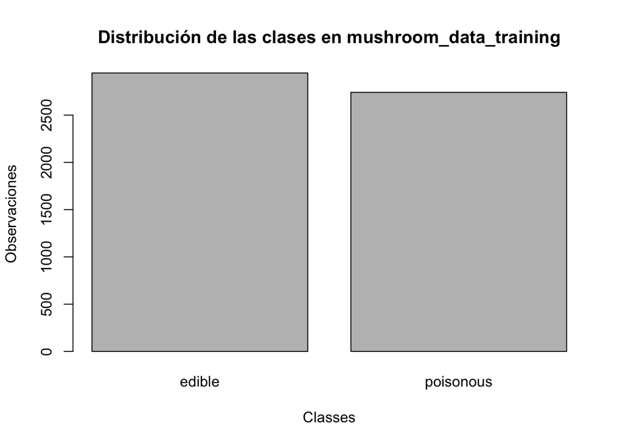

```r
# Comprobación de la distribución de clases edible y poisonous
barplot(
    table(mushroom_data_training$class),
    main = 'Distribución de las clases en mushroom_data_training',
    ylab = 'Observaciones',
    xlab = 'Classes'
)
```

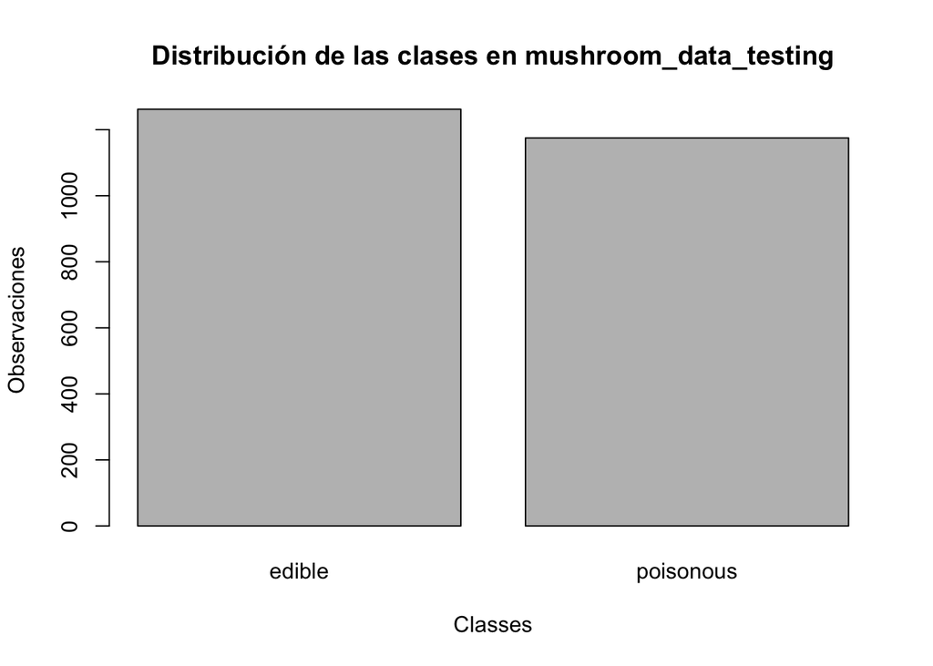

```r
barplot(
    table(mushroom_data_testing$class),
    main = 'Distribución de las clases en mushroom_data_testing',
    ylab = 'Observaciones',
    xlab = 'Classes'
)
```

### Arbol de decisiones

```r
# Modelo
mushroom_modelo_arbol_decision <-
    rpart(mushroom_formula, data = mushroom_data_training, method =  'class')

# Predicciones
mushroom_modelo_arbol_decision_predicciones <-
    predict(mushroom_modelo_arbol_decision,
            mushroom_data_testing,
            type = 'class')
```

### Regresión Logística

```r
# Modelo
mushroom_modelo_regresion_logistica <-
    glm(mushroom_formula,
        data = mushroom_data_training,
        family = 'binomial')
# Predicciones
mushroom_modelo_regresion_logistica_predicciones <-
    predict(mushroom_modelo_regresion_logistica,
            mushroom_data_testing,
            type = 'response')
```

### Random Forest

```r
# Modelo
mushroom_modelo_random_forest <-
    randomForest(mushroom_formula, data = mushroom_data_training)

# Predicciones
mushroom_modelo_random_forest_predicciones <-
    predict(mushroom_modelo_random_forest,
            newdata = mushroom_data_testing,
            type = "class")
```